# Project 2B: Disney+ Data

LINDSAY NYMAN

Thursday, December 09, 2021 @ 03:35 AM

## Setup

### Packages Used

```r
library(tidyverse)
library(ggplot2)
library(dplyr)
library(tidyr)
library(readr)
library(waffle)
library(DT)
library(janitor)
```

### Datasets Used

```r
load("../dataprocessed/streamingcontent.Rdata")
```

## Visualizations

### Background of the Data

The datasets were downloaded from [Kaggle](https://www.kaggle.com/). You can find the links to their descriptions in the `docsreference` folder.

### Create Analysis Datasets

Complete and run the two scripts found in the `docscripts` folder. Your processed datasets all should be written into the `dataprocessed` folder. Load the resulting `.Rdata` file above under the **Setup** header and use `glimpse()` to explore the structure of each dataset.

#### Dataset #1

The `dplus` dataset contains a variable that gives information about the `rating` for each program offering. Convert the variable into a factor that puts the ratings in (roughly) ascending order of age restriction/audience: `TV-Y`, `TV-Y7`, `TV-Y7-FV`, `TV-G`, `G`, `TV-PG`, `PG`, `PG-13`, `TV-14`. If the `date_added` variable is not already in date format, convert it.

```r
readRDS("../dataprocessed/dplus.rds")
```

```
# A tibble: 1,368 × 12
   show_id type    title director cast  country date_added          release_year
   <chr>   <chr>   <chr> <chr>    <chr> <chr>   <dttm>                     <dbl>
 1 s1      Movie   A Sp… Jason S… Apth… <NA>    2021-09-24 00:00:00         2021
 2 s2      Movie   Spoo… Robert … Tuck… United… 2021-09-24 00:00:00         2011
 3 s3      Movie   The … Josh Bo… Shai… United… 2021-09-24 00:00:00         2014
 4 s4      TV Show Dog:… <NA>     Matt… United… 2021-09-22 00:00:00         2019
 5 s5      TV Show Spid… <NA>     Benj… United… 2021-09-22 00:00:00         2021
 6 s6      TV Show Star… <NA>     <NA>  <NA>    2021-09-22 00:00:00         2021
 7 s7      Movie   Conf… P.J. Ho… Isla… United… 2021-09-17 00:00:00         2009
 8 s8      Movie   Desc… Salvado… Dove… <NA>    2021-09-17 00:00:00         2021
 9 s9      Movie   Disn… Jay Hat… John… <NA>    2021-09-17 00:00:00         2016
10 s10     Movie   Floo… Katie B… Devi… <NA>    2021-09-17 00:00:00         2021
# … with 1,358 more rows, and 4 more variables: rating <chr>, duration <chr>,
#   listed_in <chr>, description <chr>
```

```r
factordplus <- dplus %>% mutate(rating = factor(rating, levels = c("TV-Y", "TV-Y7", "TV-Y7-FV", "TV-G", "G", "TV-PG", "PG", "PG-13", "TV-14")))


print(factordplus)
```

```
# A tibble: 1,368 × 12
   show_id type    title director cast  country date_added          release_year
   <chr>   <chr>   <chr> <chr>    <chr> <chr>   <dttm>                     <dbl>
 1 s1      Movie   A Sp… Jason S… Apth… <NA>    2021-09-24 00:00:00         2021
 2 s2      Movie   Spoo… Robert … Tuck… United… 2021-09-24 00:00:00         2011
 3 s3      Movie   The … Josh Bo… Shai… United… 2021-09-24 00:00:00         2014
 4 s4      TV Show Dog:… <NA>     Matt… United… 2021-09-22 00:00:00         2019
 5 s5      TV Show Spid… <NA>     Benj… United… 2021-09-22 00:00:00         2021
 6 s6      TV Show Star… <NA>     <NA>  <NA>    2021-09-22 00:00:00         2021
 7 s7      Movie   Conf… P.J. Ho… Isla… United… 2021-09-17 00:00:00         2009
 8 s8      Movie   Desc… Salvado… Dove… <NA>    2021-09-17 00:00:00         2021
 9 s9      Movie   Disn… Jay Hat… John… <NA>    2021-09-17 00:00:00         2016
10 s10     Movie   Floo… Katie B… Devi… <NA>    2021-09-17 00:00:00         2021
# … with 1,358 more rows, and 4 more variables: rating <fct>, duration <chr>,
#   listed_in <chr>, description <chr>
```

#### Dataset #2

In the `strmtv` dataset, create a new variable that tells you the total number of streaming services that offer each included program.

```r
strmtv <- strmtv %>% rename_with(~ gsub('[[:punct:]]', '', .x))

strmtv <- clean_names(strmtv)


strmtv <- strmtv %>%
  rowwise() %>%
    mutate(total_sum = sum(c(netflix, hulu, prime_video, disney),na.rm = TRUE))

strmtv <- na.omit(strmtv)
print(strmtv)
```

```
# A tibble: 3,207 × 11
# Rowwise:
      id title        year age   im_db rotten_tomatoes netflix  hulu prime_video
   <dbl> <chr>       <dbl> <chr> <chr> <chr>             <dbl> <dbl>       <dbl>
 1     1 Breaking B…  2008 18+   9.4/… 100/100               1     0           0
 2     2 Stranger T…  2016 16+   8.7/… 96/100                1     0           0
 3     3 Attack on …  2013 18+   9.0/… 95/100                1     1           0
 4     4 Better Cal…  2015 18+   8.8/… 94/100                1     0           0
 5     5 Dark         2017 16+   8.8/… 93/100                1     0           0
 6     6 Avatar: Th…  2005 7+    9.3/… 93/100                1     0           1
 7     7 Peaky Blin…  2013 18+   8.8/… 93/100                1     0           0
 8     8 The Walkin…  2010 18+   8.2/… 93/100                1     0           0
 9     9 Black Mirr…  2011 18+   8.8/… 92/100                1     0           0
10    10 The Queen'…  2020 18+   8.6/… 92/100                1     0           0
# … with 3,197 more rows, and 2 more variables: disney <dbl>, total_sum <dbl>
```

### Part 1: Violin Plot

Create a violin plot of `release_year` (x-axis) grouped by `type` of program (y-axis) for programs on Disney+. Fill with a color of your choice. Add a boxplot inside the violin plot, as you did in one of the DataCamp exercises. Re-scale the x-axis so that tick marks appear at whole-decade intervals (e.g., 1980, 1990, 2000). Add an appropriate title and axis labels. Use other formatting as you choose to enhance effectiveness/appearance.

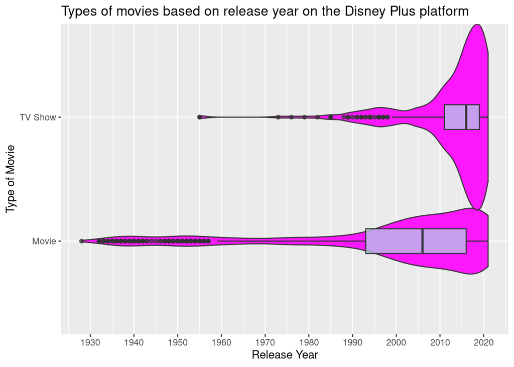

```r
violin_plot <- ggplot(dplus, aes(x = release_year, y = type, fill = release_year)) +
                geom_violin(fill = "magenta", alpha = .9, width = 1.5) +
                scale_x_continuous(breaks = c(1920,1930, 1940, 1950, 1960, 1970, 1980, 1990, 2000, 2010, 2020, 2030)) +
                labs(title= "Types of movies based on release year on the Disney Plus platform", x = "Release Year", y = "Type of Movie") +
                geom_boxplot(fill = "lightblue", alpha = .7, width = .2)

print(violin_plot)
```

[figure not shown]

Hint: You can use `count()` to find out how many of each `type` of program there is, then use `prop.table(n)` in a mutate statement (along with some other math) to get percentages. Other methods are also possible.

### Part 3: Bar Plot

Create a horizontal barplot to show the frequencies of the various `rating` categories for programs on Disney+ (i.e., use `y =` rather than `x =` for the variable you are plotting). Use faceting by `type` so that you have side-by-side plots for the different program types. Add an appropriate title and axis labels, as well as other formatting of your choice to enhance effectiveness/appearance.

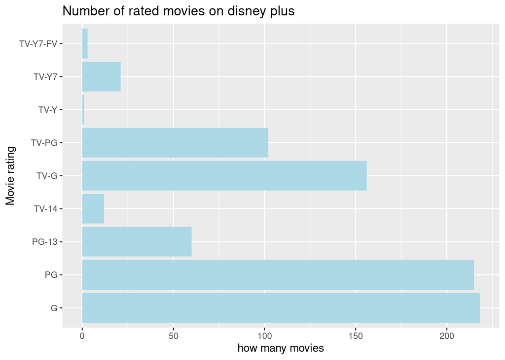

```r
dplus <- na.omit(dplus)
barplotH <- ggplot(dplus, aes( y = rating)) +
            geom_bar(fill = "lightblue")+
            labs(title = "Number of rated movies on disney plus", x = "how many movies", y = "Movie rating")


print(barplotH)
```

## Question

**Question 1:** Based on your plots, make five informational statements or comparisons regarding the Disney+ streaming service.

**ANSWER**

1. Disney Plus provides almost equal amounts of G and Pg rated movies on its platform.
2. Disney plus provides movies that are released more recently. When you look at the Violin plot it is weighted much heavier twards the modern date.
3. Almost all of Disney Plus’ movie selection were made in the United States.
4. Disney Plus has slightly more movies on its platform compared to TV shows.
5. On the whole TV shows were released later so it is in a way skewed towards having more movies on the platform due to movies being more popular in earlier years.

**Question 2:** What other data would you like to have, or which existing variables would you like to see transformed, if you were going to do further explorations or visualizations? Give at least two examples.

**ANSWER** I think I would like to have had genre of movies included because it could provide some clarity on which streaming platforms have certain types of movies. When displaying info about movies to me genre is really important.